# HW 1: Анализ данных о самолетах, авиалиниях и аэропортах с целью создания рекомендаций для заказчика

Скворцов Глеб, goskvortsov

## Задача

на основе данных (и выданных вопросов) постараться выяснить:

- какие проблемы есть в авиаперевозках
- какие улучшения можно предложить на основе выводов по данным

#### Загрузка данных и преобразование

### Вопросы

#### Вопрос 1

**Вопрос:** Пишут ли люди более добрые отзывы на авиалинии в выходные?

**Данные:** для ответа на вопрос нужна единственная таблица airline

Создадим новый датафрейм “responses”, в котором будет две переменные: “overall_rating” со значениями оценок клиентов и “IsWeekend”, где будут обозначены, является ли день оставления отзыва выходным. В результате работы с данными было обнаружено 76 пустых значений в колонке “overall_rating”. Это значение достаточно велико относительно всего датасета (около 8%), следовательно, заполнение средними значениями дало бы сильный перекос данных. Осталось два варианта чистки данных: 1. Заполнение значений методом алгоритмов supervised learning (например, RandomForest). Предполагалось решение задачи классификации. Однако, данный метод был отброшен из-за возможной некачественной обработки текста комментариев клиента. 2.Было принято решение сделать дроп данных с пропущенными значениями для минимизации риска возможной ошибки.

Следующим шагом стало решение о построении графика boxplot для сопоставления средних значений и возможных отклонений между оценками по выходным и рабочим дням.

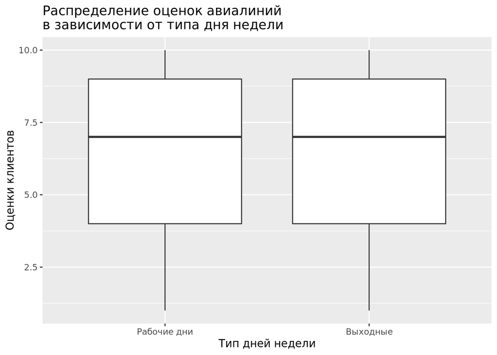

Удивительным фактом оказалось то, что значения графика boxplot оказались одинаковыми, из-за чего появилась потребность проверить значения mean, standard deviation и в целом посмотреть на распределения оценок.

mean выходных дней:

```
## [1] 6.211429
```

mean рабочих дней:

```
## [1] 6.282842
```

std выходных дней:

```
## [1] 3.080507
```

std рабочих дней:

```
## [1] 3.041397
```

Распределение:

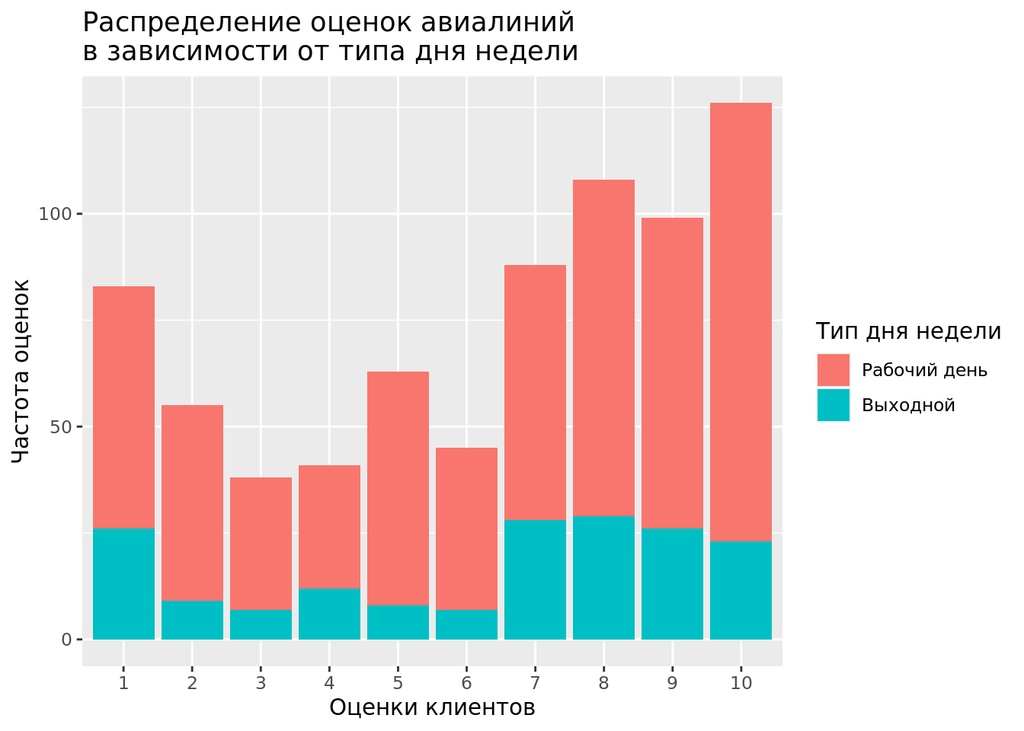

Как видим, значение mean среди двух групп различается минимально, как и значение standard deviation (std довольно велико). График показывает, что респределение похоже на бимодальное пуассоновское (так как величины дискретные), а тренды частот оценок между двумя типами дней недели сохраняются.

На первый взгляд такого обоснования для принятия решения о независимости признака “Тип дня недели” и признака “Оценка клиентов” достаточно. Однако с связи с ограниченным набором данных в предоставленном датасете и тем фактом, что данных о рабочих днях гораздо больше, чем данных о выходных, было принято решение построить доверительные интервалы для средних значений в нормальном распределении, так как (основываясь на том, что по центральной предельной теореме бимодальное пуассоновское распределение с независимыми одинаково распределенными величинами на увеличенных объемах выборки быстро стремится к нормальному распределению). Для данной работы была установлена и импортирована библиотека DescTools

```
##     mean   lwr.ci   upr.ci
## 6.211429 5.755023 6.667834
```

```
##     mean   lwr.ci   upr.ci
## 6.282842 6.061787 6.503897
```

Результаты показали, что с вероятностью 95% наши доверительные интервалы сильно пересекаются, что может быть достаточнм обоснованием их равенства на всей популяции, и, как следствие, отсутствия зависимостей между признаками “Тип дня недели” и “Оценка клиентов”.

**Ответ:** Клиентские оценки авиалиний не изменяются в зависимости от типа дня недели (выходной или рабочий день), эти признаки не взаимосвязаны.

**Вывод:** В данном случае существует 2 рекомендации: если для компании данный фактор является ключевым, стоит рассмотреть иные его вариации (например, проследить зависимость между оценками по праздничным дням и в обычные дни). С другой стороны, если данной фактор не является ключевым для компании, не стоит использовать его для дальнейшей деятельности, так как он не является информативным.

#### Вопрос 2

**Вопрос:** “В каких самолетах более высокие оценки ширины кресла — те, в которых два прохода или один?”

**Данные:** для ответа на вопрос нужна единственная таблица seat.

Создадим датасет responses_wid, которые будет содержать оценки ширины кресел и данные о количестве проходов в самолете. Для получения инфомации о количестве проходов используется библиотека stringr. В датасете было удалено одно значение, которое содержало Deck в колонке количества проходов.

Построим график boxplot для получения информации о распределениях оценок в зависимости от количества проходов. Boxplot даст информацию не только о средних оценках, но и об отклонениях, что позволит сделать более качественный анализ.

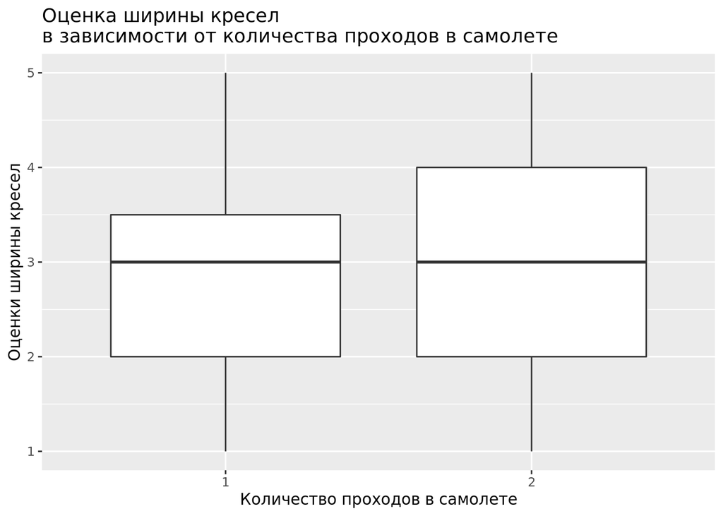

На графике видно, что медианные значения равны, но значения 0,75 квантиля разнятся. На первый взгляд можно сказать, что если у самолетов с двумя проходами 0,75 квантиль больше, чем та же точка у самолетов с одним проходом, то ширина кресел самолетов с двумя проходами оценена выше. Однако, можно заметить, что количество наблюдения по самолетов с одним проходом гораздо меньше (27 против 120 наблюдений).

Следовательно, можно предположить, что если количество наблюдений по самолетам с одним проходом будет столько же, сколько и наблюдений по самолетам с двумя проходами, то их новые отклонения изменят наш вывод. Чтобы рассмотреть эту гипотезу, нам стоит узнать зачения среднего (mean) и отклонения (standard deviation) и оценить распределения данных величин.

mean ширины кресел самолетов с 1 проходом:

```
## [1] 2.740741
```

mean ширины кресел самолетов с 2 проходами

```
## [1] 2.833333
```

std ширины кресел самолетов с 1 проходом:

```
## [1] 1.163304
```

std ширины кресел самолетов с 2 проходами:

```
## [1] 1.343101
```

Среднее значение самолетов с двумя выходами больше, чем с одним. Также у самолетов с двумя выходами значение отклонения аналогично выше (сами значения отклонений довольно высоки). Однако это не опровергает нашу гипотезу о том, что такие значения получаются за счет большего количества значений, чем в самолетах с одним выходом.

Далее мы можем посмотреть и оценить распределения двух данных переменных в зависимости от количества выходов в самолетах.

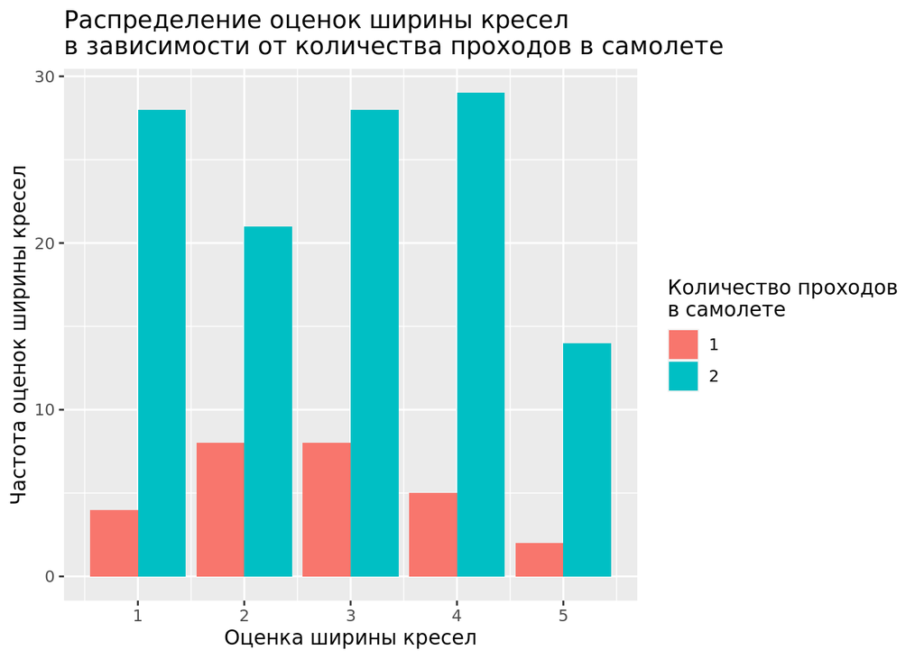

На данном графике видно, что распределения величин разнятся: распределение оценок ширины кресла в самолетах с одним проходам похоже на стандартное пуассоновское распределение, а с двумя проходами - на бимодальное пуассоновское с пиками на оценке 1 и 4 (так как величины дискретные).

В результате анализа получили 2 распределения. В соответствии с центральной предельной теоремой при больших объемах выборок такие пуассоновские с независимыми одинаково распределенными величинами быстро сводятся к нормальным (так как наш датасет включает лишь маленькую часть из общего датасета). Поэтому мы можем оценить доверительные интервалы среднего значения нормального распределения и сравнить их.

```
##     mean   lwr.ci   upr.ci
## 2.740741 2.301948 3.179534
```

```
##     mean   lwr.ci   upr.ci
## 2.833333 2.625196 3.041471
```

Как видим, с 95% вероятностью оцененный интервал для среднего по всей популяции для самолетов с одним проходом покрывает такой же интервал для среднего по всей популяции для самолетов с двумя проходами.

Следовательно, можно практически с полной уверенностью сказать, что внутри нашей выборки оценка ширины кресел для самолетов с двумя проходами выше, чем самолетов с одним проходом (из-за более высокого 0,75 квантиля). Однако, рассуждая об оценке для всей популяции, можно сказать, что средние значения этих подвыборок сильно не отличаются.

**Ответ:** Если вывод формируется исключительно на основе данной выборки, то ширина кресел у самолетов с двумя проходами оценена выше, чем ширина кресел у самолетов с одним проходом. Если же формировать вывод по оценке для всей популяции - разница между оценками ширины кресел дляя двух типов самолетов не критична: ее не стоит выделять.

**Вывод:** Если предоставленный компанией датасет является по ее оценкам достаточно репрезентативным и его анализ способен предоставить компании всю нужную информацию: заказчику стоит сделать анализ взаимосвязи параметров “оценка ширина кресел” и “общая оценка полета”. Если в результате такого анализа будет определено, что у данных параметров имеется взаимосвязь, а также есть положительная корелляция между общей оценкой полета и частотой использования услуг данной авиакомпании, то мы можем сказать, что заказчику стоит нарастить штаб самолетов с двумя проходами, так как это увеличит использование его услуг. Если же данный датасет не является достаточно репрезентативным, то стоит обратить внимание на оценку всей популяции, которая не показала взаимосвязь между количеством проходов в самолете и оценками ширины кресел. Заказчик может: 1)найти другой параметр, который будет иметь положительную корелляцию с потребительским спросом и, если этот параметр будет зависеть от количества проходов в самолете - нарастить штаб самолетов с таким количеством проходов. 2)если же сравнение именно этих параметров имеет важность для будущего проекта - стоит убрать данные параметры из рассмотрения, так как анализ не показал информативность такого сравнения.

#### Вопрос 3

**Вопрос:** “Какие лаунж-зоны оценены по качеству wi-fi выше, чем аэропорты, в которых они расположены?”

**Данные:** для ответа на вопрос нужны таблицы: lounge, airport

1. Для начала нам нужно создать основу для сравнения: создадим переменные AirportName и LoungeName, которые будут содержать обработанные значения названий аэропортов м лаунж-зон (соответственно). В дальнейшем они будут использованы для объединения таблиц и группировки значений.
2. Теперь нам нужно взять переменные качества wifi и название аэропортов и лаунж-зон для lounge и airport (создаем переменные lounge2 и airport2 соответственно). Удалим пустые значения, так как они не позволят сделать корректное сравнение в дальнейшем.
3. Объединим таблицы по названию аэропорта. Далее сгруппируем значения по названию лаунж-зон, а также выведем средние значения оценок качества wi-fi для каждой уникальной лаунж-зоны и аэропорта, в котором эти лаунж-зоны находятся. Удалим значения, которые не являются названием лаунж-зоны (возможно, являются ошибками). Отфильтруем получившийся датасет по признаку того, что средняя оценка качества wi-fi лаунж-зоны выше, чем такая оценка по аэропорту.

Небольшое количество значений объясняется тем, что не для всех лаунж-зон мы можем увидеть данные по оценке качества wi-fi самой лаунж-зоны и аэропорта.

Теперь построим график barplot средней оценки качества wi-fi для лаунж-зон (цветом разделим оценки лаунж-зон и аэропортов).

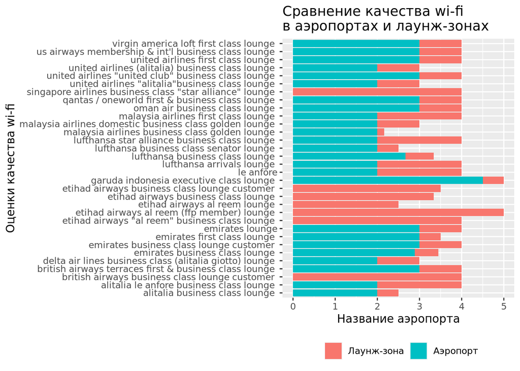

На графике видны те лаунж-зоны, средние оценки качества wi-fi которых выше, чем средние оценки аэропортов, в которых такие лаунж-зоны находятся.

**Ответ:** Аэропорты, в которых оценки качества wi-fi в лаунж-зонах выше, чем в самих аэропортах: alitalia business class lounge, alitalia le anfore business class lounge, british airways business class lounge customer, british airways terraces first & business class lounge, delta air lines business class (alitalia giotto), emirates first class lounge, emirates lounge, etihad airways "al reem" business class lounge, etihad airways al reem (ffp member) lounge, etihad airways al reem lounge, etihad airways business class lounge, etihad airways business class lounge customer, garuda indonesia executive class lounge, le anfore, lufthansa arrivals lounge, lufthansa business class lounge, lufthansa business class senator lounge, lufthansa star alliance business class lounge, malaysia airlines business class golden lounge, malaysia airlines domestic business class golden lounge, malaysia airlines first class lounge, oman air business class lounge, qantas / oneworld first & business class lounge, singapore airlines business class "star alliance" lounge, united airlines "alitalia"business class lounge, united airlines "united club" business class lounge, united airlines (alitalia) business class lounge, united airlines first class lounge, us airways membership & int’l business class lounge, virgin america loft first class lounge.

**Вывод:** В этих аэропортах заказчику стоит сделать анализ параметров спроса и качества wi-fi в аэропорте. Если между этими параметрами будет положительная корелляция, то внутри данных аэропортов стоит улучшить качество wi-fi - это увеличит показатели спроса. С другой стороны, если корелляция будет близка к нулю (или равна нулю), то улучшение качества wi-fi не будет являться необходмой задачей и в случае наличия более фундаментальных инициатив появится возможность временно отклонить данную задачу. Также заказчику стоит развить систему сбора отзывов потребителей о качестве wi-fi (например, проводить опросы в зале ожидания перед полетом). Это позволит сделать более качественный анализ этого параметра в будущем.

### Дэшборд

Полученные выводы обобщены в виде дэшборда со следующими элементами

**Элемент 1:** - вид: график - ответ на вопрос: 3 - обоснование: график показывает, в каких аэропортах оценка качества wi-fi внутри лаунж-зоны выше, чем в аэропорте. Тип графика (bar plot) выбран из-за того, что лаунж-зона является категориальной переменной и нам нужно сделать сравнение внутри такой переменной.

**Элемент 2:** - вид: числа - ответ на вопрос: 1 - обоснование: Позволяет сделать оценку генеральной совокупности отзывов на основе типа дня недели (выходной или рабочий день). Сделано для проверки показателей внутри выборки, если она не будет являться репрезентативной для заказчика. Дает возможность быть уверенным в выводах, основанных на выборке.

**Элемент 3:** - вид: график - ответ на вопрос: 2 - обоснование: боксплот позволяет учесть не только средние значения, но и отклонения. Это позволяет сделать более объективный анализ внутри данной выборки. Если мы говорим, что данная выборка - репрезентативна относительно всей популяции - информация об отклонениях сможет снизить риск неверного анализа. **Элемент 4:** - вид: числа - ответ на вопрос: 2 - обоснование: доверительынй интервал для среднего позволяет сделать оценку генеральной совокупности отзывов о ширины кресел среди самолетов с одним и двумя проходами. Он нужен для того, чтобы проверить, является ли малость значений внутри выборки важным показателям для наших последующих выводов. Здесь доверительные интервалы позволили нам изменить наш вывод (в сторону осутствия значимых различий между средними показателями подвыборок), в том случае, если данная выборка окажется не достаточно репрезентативной.

### Общие выводы

В результате нашего анализа мы: 1)сделали вывод из данных на основе выборки; 2)сделали оценку генеральной совокупности (где было необходимо ее сделать); 3)Сделали выводы для заказчика (учтя возможные различия между выводами на основе выборки и всей популяции). В зависимости от рода деятельности заказчика, он смог получить практические рекомендации к своей деятельности, которые были подкреплены достаточно глубоким анализом взаимосвязей внутри предоставленных датасетов.